# Galaxy Image Classification

### Predictions.csv

```python
import pandas as pd
import numpy as np

predictions = pd.read_csv('predictions.csv')
predictions.head()
```

|  | GalaxyID | Class1.1 | Class1.2 | Class1.3 | Class2.1 | Class2.2 | Class3.1 | Class3.2 | Class4.1 | Class4.2 | ... | Class9.3 | Class10.1 | Class10.2 | Class10.3 | Class11.1 | Class11.2 | Class11.3 | Class11.4 | Class11.5 | Class11.6 |
| --- | --- | --- | --- | --- | --- | --- | --- | --- | --- | --- | --- | --- | --- | --- | --- | --- | --- | --- | --- | --- | --- |
| 0 | 100008 | 0.383147 | 0.616853 | 0.000000 | 0.000000 | 0.616853 | 0.038452 | 0.578401 | 0.418398 | 0.198455 | ... | 0.000000 | 0.279952 | 0.138445 | 0.000000 | 0.000000 | 0.092886 | 0.0 | 0.0 | 0.0 | 0.325512 |
| 1 | 100023 | 0.327001 | 0.663777 | 0.009222 | 0.031178 | 0.632599 | 0.467370 | 0.165229 | 0.591328 | 0.041271 | ... | 0.018764 | 0.000000 | 0.131378 | 0.459950 | 0.000000 | 0.591328 | 0.0 | 0.0 | 0.0 | 0.000000 |
| 2 | 100053 | 0.765717 | 0.177352 | 0.056931 | 0.000000 | 0.177352 | 0.000000 | 0.177352 | 0.000000 | 0.177352 | ... | 0.000000 | 0.000000 | 0.000000 | 0.000000 | 0.000000 | 0.000000 | 0.0 | 0.0 | 0.0 | 0.000000 |
| 3 | 100078 | 0.693377 | 0.238564 | 0.068059 | 0.000000 | 0.238564 | 0.109493 | 0.129071 | 0.189098 | 0.049466 | ... | 0.000000 | 0.094549 | 0.000000 | 0.094549 | 0.189098 | 0.000000 | 0.0 | 0.0 | 0.0 | 0.000000 |
| 4 | 100090 | 0.933839 | 0.000000 | 0.066161 | 0.000000 | 0.000000 | 0.000000 | 0.000000 | 0.000000 | 0.000000 | ... | 0.000000 | 0.000000 | 0.000000 | 0.000000 | 0.000000 | 0.000000 | 0.0 | 0.0 | 0.0 | 0.000000 |

5 rows × 38 columns

There seems to be ambigious headings for our columns and the resources on Kaggle don't seem to help much. Essentially, the classes refer to the morphology on the galaxy.

```python
#All of the classes in our Class1 add up to 1. These classes refer to the probaility of
#the galaxy being either the shape in Class1.1, Class1.2, or in Class1.3.

(predictions['Class1.1'] + predictions['Class1.2'] + predictions['Class1.3']).head()
```

```
0    1.0
1    1.0
2    1.0
3    1.0
4    1.0
dtype: float64
```

```python
#Dropping all the other columns which do not refer to the morphology.
predictions = predictions[['GalaxyID','Class1.1', 'Class1.2', 'Class1.3']]
predictions.head(10)
```

|  | GalaxyID | Class1.1 | Class1.2 | Class1.3 |
| --- | --- | --- | --- | --- |
| 0 | 100008 | 0.383147 | 0.616853 | 0.000000 |
| 1 | 100023 | 0.327001 | 0.663777 | 0.009222 |
| 2 | 100053 | 0.765717 | 0.177352 | 0.056931 |
| 3 | 100078 | 0.693377 | 0.238564 | 0.068059 |
| 4 | 100090 | 0.933839 | 0.000000 | 0.066161 |
| 5 | 100122 | 0.738832 | 0.238159 | 0.023009 |
| 6 | 100123 | 0.462492 | 0.456033 | 0.081475 |
| 7 | 100128 | 0.687783 | 0.288344 | 0.023873 |
| 8 | 100134 | 0.021834 | 0.976952 | 0.001214 |
| 9 | 100143 | 0.269843 | 0.730157 | 0.000000 |

```python
predictions.columns = ['GalaxyID', 'Elliptical', 'Spiral', 'Irregular']
predictions.head()
```

|  | GalaxyID | Elliptical | Spiral | Irregular |
| --- | --- | --- | --- | --- |
| 0 | 100008 | 0.383147 | 0.616853 | 0.000000 |
| 1 | 100023 | 0.327001 | 0.663777 | 0.009222 |
| 2 | 100053 | 0.765717 | 0.177352 | 0.056931 |
| 3 | 100078 | 0.693377 | 0.238564 | 0.068059 |
| 4 | 100090 | 0.933839 | 0.000000 | 0.066161 |

If the value in the irregular was the max value for that row, we called it an irregular.

Note: The following code below no longer works because the irregular folders are deleted.

```
print('num in train elliptical = {}'.format(len(os.listdir('data/train/elliptical/'))))
print('num in train spiral = {}'.format(len(os.listdir('data/train/spiral/'))))
print('num in train irregular = {}'.format(len(os.listdir('data/train/irregular/'))))
print('num in test elliptical = {}'.format(len(os.listdir('data/test/elliptical/'))))
print('num in test spiral = {}'.format(len(os.listdir('data/test/spiral/'))))
print('num in test irregular = {}'.format(len(os.listdir('data/test/irregular/'))))
```

num in train elliptical = 13237  
num in train spiral = 17526  
num in train irregular = 26  
num in test elliptical = 13456  
num in test spiral = 17300  
num in test irregular = 33

For this, we can remove the irregular images since they make such a small portion of our over all dataset.

Now, let's delete the irregular galaxies from the predictions (because we deleted their images). Then we will drop the "Irregular" column.

```python
len(predictions[(predictions.Irregular > predictions.Spiral) & (predictions.Irregular > predictions.Elliptical)])
```

```
59
```

```python
predictions[(predictions.Irregular > predictions.Spiral) & (predictions.Irregular > predictions.Elliptical)].head()
```

|  | GalaxyID | Elliptical | Spiral | Irregular |
| --- | --- | --- | --- | --- |
| 1791 | 126783 | 0.178000 | 0.044000 | 0.778000 |
| 2376 | 135453 | 0.360342 | 0.098619 | 0.541039 |
| 6957 | 202788 | 0.242413 | 0.290022 | 0.467565 |
| 7434 | 209411 | 0.273749 | 0.202910 | 0.523342 |
| 7557 | 211113 | 0.289000 | 0.133000 | 0.578000 |

```python
#Dropped all the irregular galaxies.
predictions.drop(predictions[(predictions.Irregular > predictions.Spiral) & (predictions.Irregular > predictions.Elliptical)].index,inplace=True)
```

```python
predictions.drop(['Irregular'], axis=1, inplace=True)
```

```python
predictions.head()
```

|  | GalaxyID | Elliptical | Spiral |
| --- | --- | --- | --- |
| 0 | 100008 | 0.383147 | 0.616853 |
| 1 | 100023 | 0.327001 | 0.663777 |
| 2 | 100053 | 0.765717 | 0.177352 |
| 3 | 100078 | 0.693377 | 0.238564 |
| 4 | 100090 | 0.933839 | 0.000000 |

```python
import matplotlib.pyplot as plt
import numpy as np
import os, shutil
from keras import models
from keras import layers
from keras.layers import Dropout
from sklearn.metrics import confusion_matrix, f1_score
np.random.seed(123)
from keras.models import load_model
from keras.preprocessing.image import ImageDataGenerator, array_to_img, img_to_array, load_img
```

```python
# get all the data in the directory split/test, and reshape them
datagen = ImageDataGenerator(rescale=1./255,
                            rotation_range=90,
                            brightness_range=(0.5,2),
                            )

#Take 30000 images from the training folder and resize images down to 106 x 106 px
data_tr=datagen.flow_from_directory(
        'data/train',
        target_size=(106, 106), #actual image size
        batch_size = 30000,
        class_mode='binary',
        seed = 123)
```

```
Found 30763 images belonging to 2 classes.
```

```python
#Take 20000 images from the testing folder and resize images down to 106 x 106 px
data_te = ImageDataGenerator(rescale=1./255).flow_from_directory(
        'data/test',
        target_size=(106, 106),
        batch_size = 20000,
        class_mode='binary',
        seed = 123)
```

```
Found 30756 images belonging to 2 classes.
```

```python
# Defining x_train, y_train, and x_test, y_test by grabbing the first 30,000 batch for train
# and 20,000 image batch for test

x_tr, y_tr = next(data_tr)
x_te, y_te = next(data_te)
```

```python
#Displaying that our training data is binary

y_tr[:5]
```

```
array([1., 1., 0., 0., 1.], dtype=float32)
```

```python
#Splitting our data using sklearn. 80% of our data is X_train, y_train - what we are training
#our model on. 20% of our data is the X_val, y_val what we are testing our data on.

from sklearn.model_selection import train_test_split
X_train, X_val, y_train, y_val = train_test_split(x_tr, y_tr, test_size=0.20, random_state=123)
```

```python
len(x_te)
```

```python
X_val.shape
```

## CNN Architecture

```python
cnn = models.Sequential()
cnn.add(layers.Conv2D(64, (3, 3), kernel_regularizer=regularizers.l2(0.1), input_shape=(106, 106, 3), padding='valid',strides=(2,2)))
cnn.add(layers.Conv2D(64, (3, 3), input_shape=(106, 106,  3), padding='valid',strides=(2,2)))
cnn.add(layers.BatchNormalization())
cnn.add(layers.Activation('relu'))
cnn.add(layers.MaxPooling2D((2, 2)))
cnn.add(Dropout(0.5))
cnn.add(layers.Conv2D(64, (3, 3), kernel_regularizer=regularizers.l2(0.1)))
cnn.add(layers.BatchNormalization())
cnn.add(layers.Activation('relu'))
cnn.add(layers.MaxPooling2D((2, 2)))
cnn.add(layers.Flatten())

cnn.add(layers.Dense(128))
cnn.add(layers.BatchNormalization())
cnn.add(layers.Activation('relu'))

cnn.add(layers.Dense(32, activation='relu'))
cnn.add(layers.Dense(1, activation='sigmoid'))


# decay_rate = learning_rate / epochs
sgd = optimizers.SGD(lr=0.01, decay=0.0002, momentum=0.9, nesterov=False)
cnn.compile(loss='binary_crossentropy',
              optimizer=sgd,
              metrics=['acc'])

cnn.load_weights('model_weights/cnn11_only_lr.h5')
```

[output not shown]

## Fitting CNN Model

```python
cnn1 = cnn.fit(X_train, y_train,
                epochs=50,
                validation_data=(X_val, y_val),
                batch_size=500)
```

```python
print(cnn.summary())
```

[output not shown]

## Let's see what our CNN is doing behind the scenes when it is fed this image:

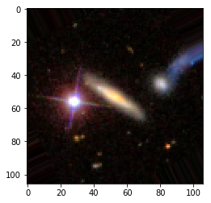

```python
# Printing one random image to compare with the hidden layers below.

plt.imshow(X_train[50])
plt.show()
```

```python
# layer_outputs = [layer.output for layer in cnn.layers[:8]]
```

```python
layer_outputs = [layer.output for layer in cnn.layers]
```

```python
cnn.layers
```

```
[<keras.layers.convolutional.Conv2D at 0x3c50b1630>,
 <keras.layers.convolutional.Conv2D at 0x3c540b5f8>,
 <keras.layers.normalization.BatchNormalization at 0x3c50bb0b8>,
 <keras.layers.core.Activation at 0x3c50a82b0>,
 <keras.layers.pooling.MaxPooling2D at 0x13ee3f400>,
 <keras.layers.core.Dropout at 0x3c50a51d0>,
 <keras.layers.convolutional.Conv2D at 0x3c542cf28>,
 <keras.layers.normalization.BatchNormalization at 0x3c50a8710>,
 <keras.layers.core.Activation at 0x3c547cd68>,
 <keras.layers.pooling.MaxPooling2D at 0x3c547ce10>,
 <keras.layers.core.Flatten at 0x3c54ba7f0>,
 <keras.layers.core.Dense at 0x3c54e7f28>,
 <keras.layers.normalization.BatchNormalization at 0x3c54cea90>,
 <keras.layers.core.Activation at 0x3c55a1dd8>,
 <keras.layers.core.Dense at 0x3c55a1e48>,
 <keras.layers.core.Dense at 0x3c55a1198>]
```

```python
activation_model = models.Model(inputs=cnn.input, outputs=layer_outputs)
```

```python
from keras import models
```

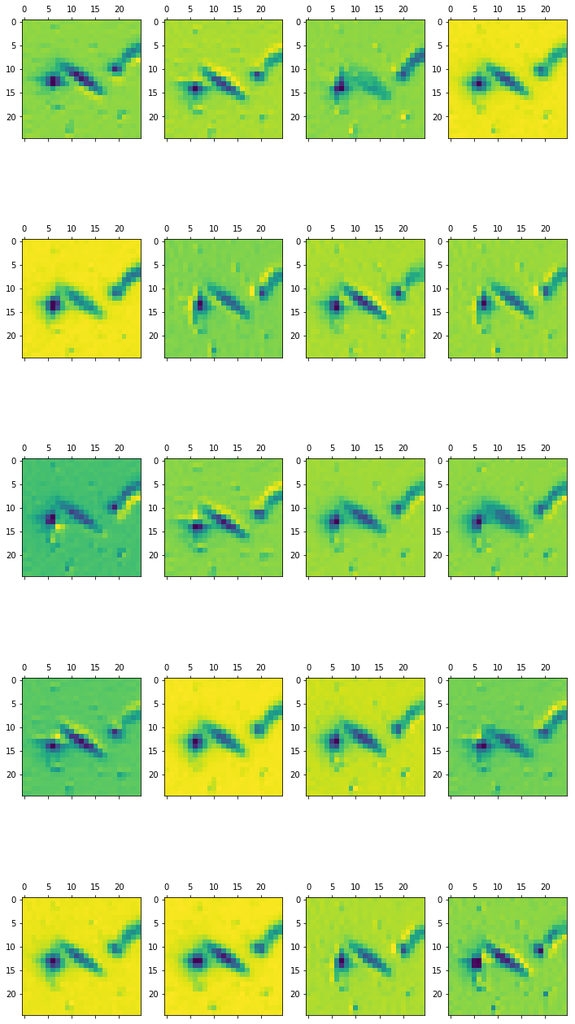

```python
# from keras import models
from keras.preprocessing import image

activations = activation_model.predict(X_train)

fig, axes = plt.subplots(5, 4, figsize=(12,24))
for i in range(20):
    row = i//4
    column = i%4
    ax = axes[row, column]
    first_layer_activation = activations[1]
    ax.matshow(first_layer_activation[50, :, :, i], cmap='viridis')
```

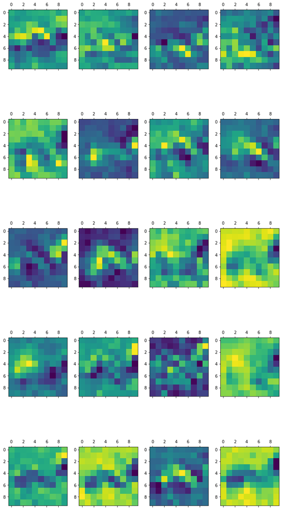

```python
# from keras import models
from keras.preprocessing import image

activations = activation_model.predict(X_train)

fig, axes = plt.subplots(5, 4, figsize=(12,24))
for i in range(20):
    row = i//4
    column = i%4
    ax = axes[row, column]
    first_layer_activation = activations[7]
    ax.matshow(first_layer_activation[50, :, :, i], cmap='viridis')
```

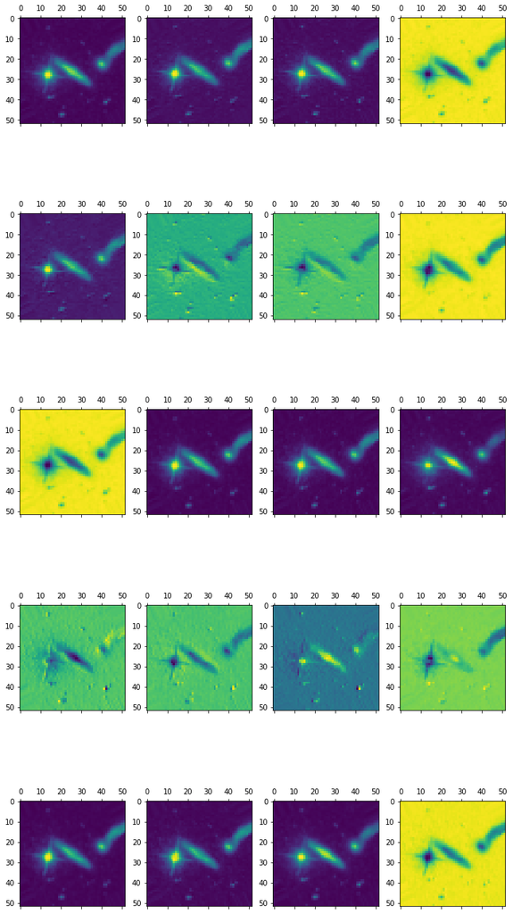

```python
# from keras import models
from keras.preprocessing import image

activations = activation_model.predict(X_train)

fig, axes = plt.subplots(5, 4, figsize=(12,24))
for i in range(20):
    row = i//4
    column = i%4
    ax = axes[row, column]
    first_layer_activation = activations[0]
    ax.matshow(first_layer_activation[50, :, :, i], cmap='viridis')
```

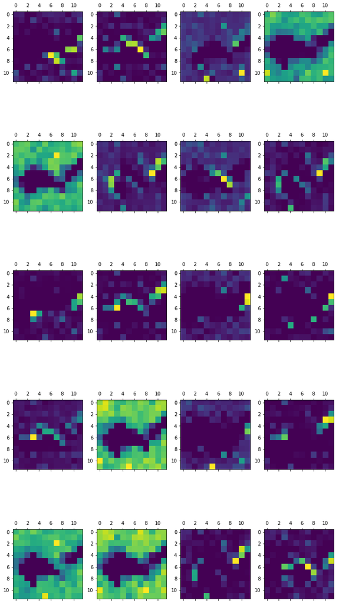

```python
# from keras import models
from keras.preprocessing import image

activations = activation_model.predict(X_train)

fig, axes = plt.subplots(5, 4, figsize=(12,24))
for i in range(20):
    row = i//4
    column = i%4
    ax = axes[row, column]
    first_layer_activation = activations[5]
    ax.matshow(first_layer_activation[50, :, :, i], cmap='viridis')
```

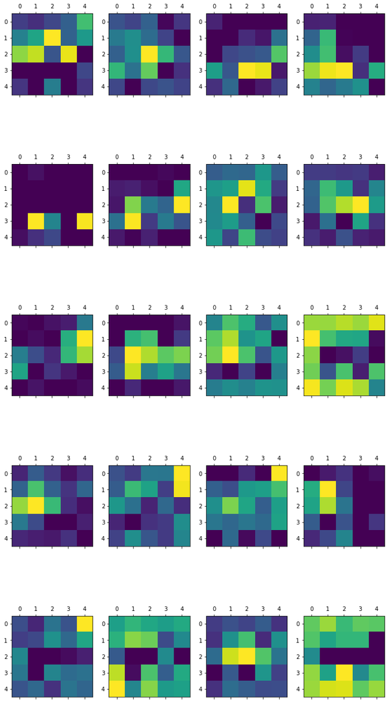

```python
# from keras import models
from keras.preprocessing import image

activations = activation_model.predict(X_train)

fig, axes = plt.subplots(5, 4, figsize=(12,24))
for i in range(20):
    row = i//4
    column = i%4
    ax = axes[row, column]
    first_layer_activation = activations[9]
    ax.matshow(first_layer_activation[50, :, :, i], cmap='viridis')
```

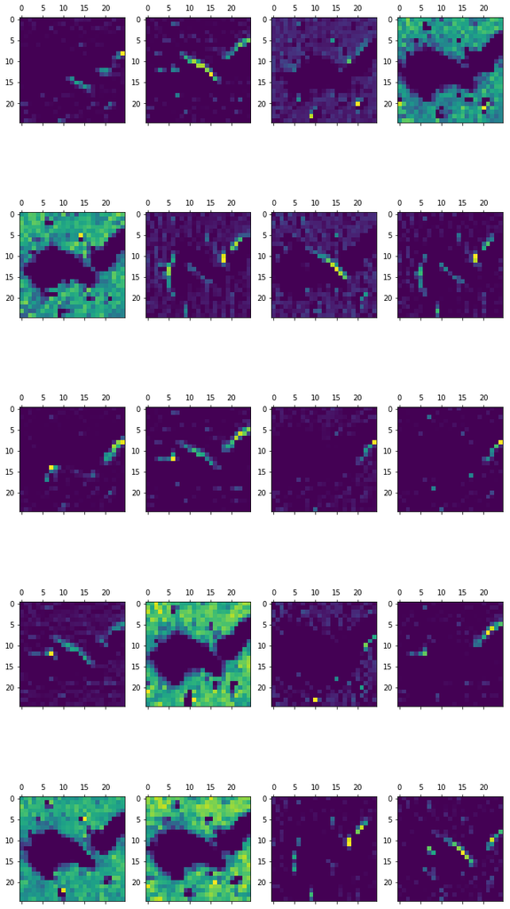

```python
# from keras import models
from keras.preprocessing import image

activations = activation_model.predict(X_train)

fig, axes = plt.subplots(5, 4, figsize=(12,24))
for i in range(20):
    row = i//4
    column = i%4
    ax = axes[row, column]
    first_layer_activation = activations[3]
    ax.matshow(first_layer_activation[50, :, :, i], cmap='viridis')
```

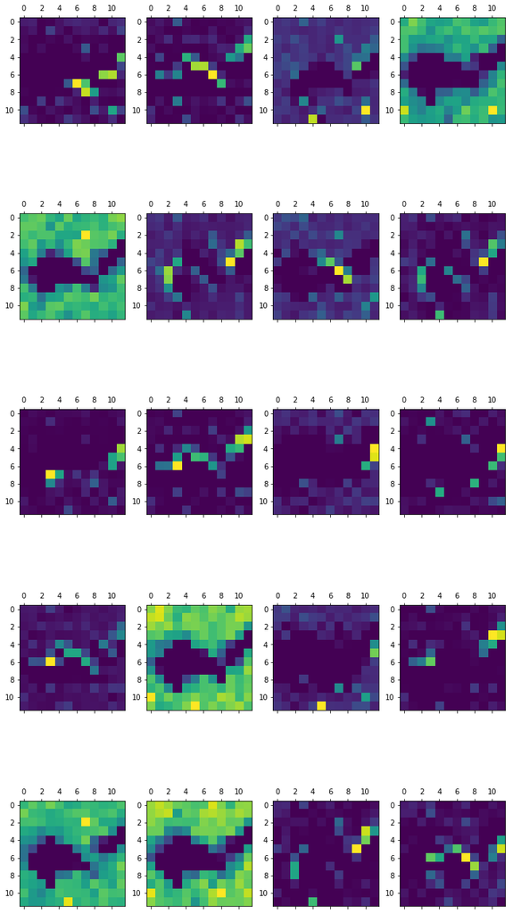

```python
# from keras import models
from keras.preprocessing import image

activations = activation_model.predict(X_train)

fig, axes = plt.subplots(5, 4, figsize=(12,24))
for i in range(20):
    row = i//4
    column = i%4
    ax = axes[row, column]
    first_layer_activation = activations[4]
    ax.matshow(first_layer_activation[50, :, :, i], cmap='viridis')
```

## Confusion Matrix for CNN

```python
cnn.evaluate(x_te, y_te)
```

```
[0.521887234210968, 0.79075]
```

```python
predictions_cnn = cnn.predict(x_te)
predictions_cnn = np.around(predictions_cnn)
```

```python
f1_score(y_te, predictions_cnn, average='macro')
```

```
0.7873114379632022
```

```
Confusion matrix, without normalization
[[6636 2109]
 [2076 9179]]
```

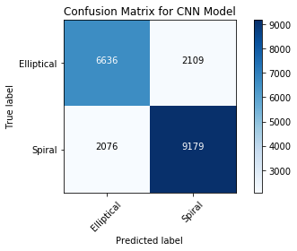

```python
plt.figure()
plot_confusion_matrix(confusion_matrix(y_te, predictions_cnn), classes=['Elliptical', 'Spiral'])
plt.title('Confusion Matrix for CNN Model')
plt.savefig('CNN_ConfusionMatrix.png')
```

## Let's test our model on some images of galaxies it has not seen yet.

```python
def predictoneimage_cnn(cnn, path):
    img = load_img(path, target_size=(106, 106))
    plt.imshow(img)
    img = img_to_array(img)
    img = img/255
    img = np.expand_dims(img, axis=0)
    predict = cnn.predict(img)
    return predict
```

#### Keras' flow_from_directory method orders folder structure alphabetical, elliptical is first, and 0 is first. So, 0 is elliptical and 1 is spiral.

```
array([[0.29584587]], dtype=float32)
```

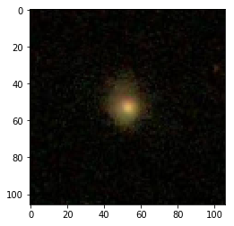

```python
predict_one_image_cnn(cnn, 'data/train/elliptical/100078.jpg')
```

```
array([[0.09924649]], dtype=float32)
```

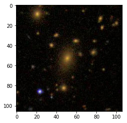

```python
predict_one_image_cnn(cnn, 'data/test/elliptical/564639.jpg')
```

#### The CNN model classified the above galaxy as an elliptical. Which is correct since this test image came from the elliptical folder.

## ROC Curve for CNN Model

```python
from sklearn.metrics import roc_curve
```

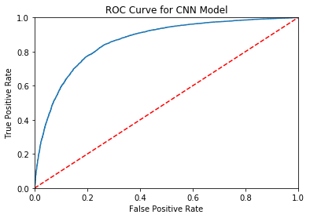

```python
fpr_cnn, tpr_cnn, thresholds = roc_curve(y_te, cnn.predict(x_te))

plt.plot(fpr_cnn,tpr_cnn)
plt.plot([0, 1], [0, 1],'r--')
plt.xlim([0, 1])
plt.ylim([0, 1])
plt.ylabel('True Positive Rate')
plt.xlabel('False Positive Rate')
plt.title('ROC Curve for CNN Model')
# plt.show()
plt.savefig('CNN_ROC.png')
```

```python
from sklearn.metrics import auc
roc_auc = auc(fpr_cnn, tpr_cnn)
```

```python
print(roc_auc)
```

```
0.8601756871159988
```

# Decision Tree

```python
from sklearn.tree import DecisionTreeClassifier
from sklearn.metrics import accuracy_score

tree_model = DecisionTreeClassifier(max_depth=10)
```

```python
x_tr.shape
```

```
(30000, 106, 106, 3)
```

```python
X_train.shape
```

```
(24000, 106, 106, 3)
```

```python
y_train.shape
```

```
(24000,)
```

```python
x_tr_flat = X_train.reshape((24000,X_train.shape[1]*X_train.shape[2]*X_train.shape[3]))
```

```python
tree_model.fit(x_tr_flat, y_train)
```

```
DecisionTreeClassifier(class_weight=None, criterion='gini', max_depth=10,
            max_features=None, max_leaf_nodes=None,
            min_impurity_decrease=0.0, min_impurity_split=None,
            min_samples_leaf=1, min_samples_split=2,
            min_weight_fraction_leaf=0.0, presort=False, random_state=None,
            splitter='best')
```

```python
x_te.shape
```

```
(20000, 106, 106, 3)
```

```python
x_te_flat = x_te.reshape((20000,x_te.shape[1]*x_te.shape[2]*x_te.shape[3]))
```

```python
y_predict = tree_model.predict(x_te_flat)
```

```python
y_predict_proba = tree_model.predict_proba(x_te_flat)
```

```python
y_predict_proba
```

```
array([[0.91032609, 0.08967391],
       [0.03174603, 0.96825397],
       [0.10344828, 0.89655172],
       ...,
       [0.06465517, 0.93534483],
       [1.        , 0.        ],
       [0.015625  , 0.984375  ]])
```

```python
accuracy_score(y_te, y_predict)
```

```
0.6887
```

```python
from sklearn.metrics import confusion_matrix

confusion_matrix(y_te, y_predict)
```

```
array([[5899, 2846],
       [3380, 7875]])
```

```
Confusion matrix, without normalization
[[5899 2846]
 [3380 7875]]
```

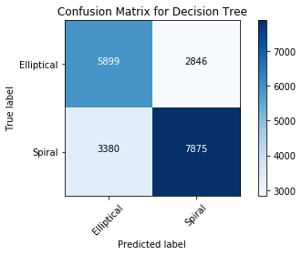

```python
plt.figure()
plot_confusion_matrix(confusion_matrix(y_te, y_predict), classes=['Elliptical', 'Spiral'])
plt.title('Confusion Matrix for Decision Tree')
plt.savefig('DecisionTree_ConfusionMatrix.png')
```

```python
y_te[:10]
```

```
array([0., 1., 1., 1., 0., 1., 0., 1., 1., 0.], dtype=float32)
```

```python
# np.unique(y_predict_proba)[:5]
y_predict_proba[:10]
```

```
array([[0.91032609, 0.08967391],
       [0.03174603, 0.96825397],
       [0.10344828, 0.89655172],
       [0.        , 1.        ],
       [0.07480315, 0.92519685],
       [0.07480315, 0.92519685],
       [0.10576923, 0.89423077],
       [0.        , 1.        ],
       [0.88823529, 0.11176471],
       [0.16923077, 0.83076923]])
```

```python
[x[1] for x in y_predict_proba][:10]
```

```
[0.08967391304347826,
 0.9682539682539683,
 0.896551724137931,
 1.0,
 0.9251968503937008,
 0.9251968503937008,
 0.8942307692307693,
 1.0,
 0.11176470588235295,
 0.8307692307692308]
```

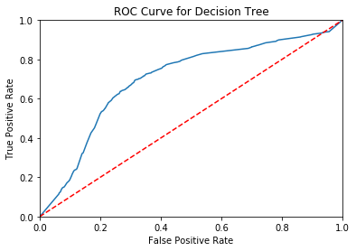

```python
from sklearn.metrics import auc, roc_curve

fpr_decision, tpr_decision, thresholds = roc_curve(y_te, [x[1] for x in y_predict_proba])

plt.plot(fpr_decision,tpr_decision)
plt.plot([0, 1], [0, 1],'r--')
plt.xlim([0, 1])
plt.ylim([0, 1])
plt.ylabel('True Positive Rate')
plt.xlabel('False Positive Rate')
plt.title('ROC Curve for Decision Tree')
# plt.show()
plt.savefig('DecisionTree_ROC.png')
```

```python
roc_auc = auc(fpr_decision, tpr_decision)
```

```python
# fpr_decision
```

```python
# tpr_decision
```

```python
print(roc_auc)
```

```
0.6984602739294575
```

# Inception

```python
#we can use any of the inception stuff even if they are trained on anything
from keras.applications import inception_v3
from keras.layers import Dense,GlobalAveragePooling2D
from sklearn.metrics import confusion_matrix, f1_score
from keras.models import Model
```

```python
imagenet=inception_v3.InceptionV3(weights='imagenet',include_top=False)
imagenet_new=imagenet.output
new_model = models.Sequential()
new_model.add(imagenet)
new_model.add(GlobalAveragePooling2D())
new_model.add(Dense(1024,activation='relu'))
new_model.add(Dense(1024,activation='relu')) #dense layer 2
new_model.add(Dense(512,activation='relu')) #dense layer 3
new_model.add(Dense(1,activation='sigmoid')) #final layer
```

```python
for i,layer in enumerate(imagenet.layers):
    print(i,layer.name, layer.trainable)
```

[output not shown]

[output cut: 296 more lines]

```python
#don't train the image net (or you will wait too long which is the first layer)
for layer in new_model.layers[:1]:
    layer.trainable=False
```

```python
new_model.compile(optimizer='Adam',loss='binary_crossentropy',metrics=['accuracy'])

# step_size_train=train_generator.n//train_generator.batch_size
new_model.fit(X_train,
          y_train,
          epochs=10,
          batch_size=50,
          validation_data=(X_val, y_val))
```

```
WARNING:tensorflow:From /anaconda3/lib/python3.7/site-packages/tensorflow/python/ops/math_ops.py:3066: to_int32 (from tensorflow.python.ops.math_ops) is deprecated and will be removed in a future version.
Instructions for updating:
Use tf.cast instead.
Train on 24000 samples, validate on 6000 samples
```

```
<keras.callbacks.History at 0xb22cce828>
```

```python
new_model.evaluate(x_te, y_te)
```

```
[0.7556947304725647, 0.5354]
```

```python
predictions_transfer = new_model.predict(x_te)
predictions_transfer = np.around(predictions_transfer)
```

```python
f1_score(y_te, predictions_transfer, average='macro')
```

```
0.5048216209418035
```

```
Confusion matrix, without normalization
[[7839  906]
 [8386 2869]]
```

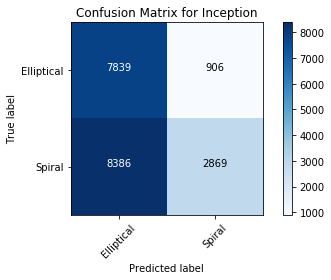

```python
plt.figure()
plot_confusion_matrix(confusion_matrix(y_te, predictions_transfer), classes=['Elliptical', 'Spiral'])
plt.title('Confusion Matrix for Inception')
plt.savefig('Inception_ConfusionMatrix.png')
```

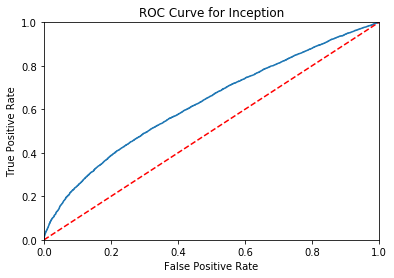

```python
fpr_inception, tpr_inception, thresholds = roc_curve(y_te, new_model.predict(x_te))

plt.plot(fpr_inception,tpr_inception)
plt.plot([0, 1], [0, 1],'r--')
plt.xlim([0, 1])
plt.ylim([0, 1])
plt.ylabel('True Positive Rate')
plt.xlabel('False Positive Rate')
plt.title('ROC Curve for Inception')
plt.savefig('Inception_ROC.png')
# plt.show()
```

### Simple Neural Network Baseline Model

```python
from keras.models import Sequential, Input
from keras.layers import Dense
model = Sequential()
```

```python
model.add(layers.Flatten(input_shape=(106, 106,  3)))
layer_1 = model.add(Dense(units=128, activation='relu'))
layer_2 = model.add(Dense(units=1, activation='sigmoid'))
```

```python
model.compile(loss='binary_crossentropy',
              optimizer='sgd',
              metrics=['acc'])
```

```python
history = model.fit(X_train, y_train,
                epochs=50,
                validation_data=(X_val, y_val),
                batch_size=500)
```

```
Train on 24000 samples, validate on 6000 samples
```

```python
# history.history['val_acc']
```

```python
predictions_mlp = model.predict(x_te)
predictions_mlp = np.around(predictions_mlp)
```

```
Confusion matrix, without normalization
[[5882 2863]
 [1612 9643]]
```

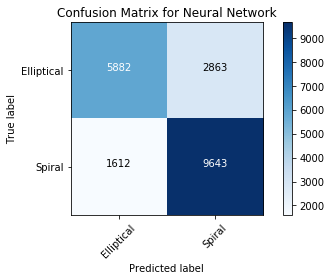

```python
plt.figure()
plot_confusion_matrix(confusion_matrix(y_te, predictions_mlp), classes=['Elliptical', 'Spiral'])
plt.title('Confusion Matrix for Neural Network')
plt.savefig('Baseline_MLP_ConfusionMatrix.png')
```

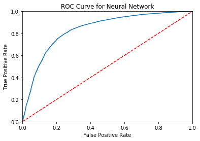

```python
fpr_neural, tpr_neural, thresholds = roc_curve(y_te, model.predict(x_te))

plt.plot(fpr_neural,tpr_neural)
plt.plot([0, 1], [0, 1],'r--')
plt.xlim([0, 1])
plt.ylim([0, 1])
plt.ylabel('True Positive Rate')
plt.xlabel('False Positive Rate')
plt.title('ROC Curve for Neural Network')
plt.savefig('BaselineMLP_ROC.png')
```

```python
fpr
```

```
array([0.        , 0.        , 0.        , ..., 0.99736993, 0.99736993,
       1.        ])
```

```python
tpr
```

```
array([0.00000000e+00, 8.88494003e-05, 1.77698801e-04, ...,
       9.99911151e-01, 1.00000000e+00, 1.00000000e+00])
```

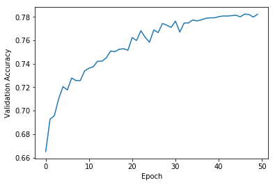

```python
plt.figure()
plt.plot(range(len(history.history['val_acc'])), history.history['val_acc'])
plt.xlabel('Epoch')
plt.ylabel('Validation Accuracy')
```

```python
loss_and_metrics = model.evaluate(x_te, y_te)
```

```python
loss_and_metrics
```

```
[0.526056180858612, 0.77625]
```

```python
model.metrics_names
```

```
['loss', 'acc']
```

```python
model.save('simple_nn_baseline.h5')
```

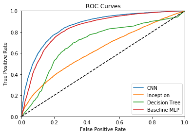

```python
# fpr_cnn, tpr_cnn, thresholds = roc_curve(y_te, cnn.predict(x_te)) # CNN -- already have
fpr_decision, tpr_decision, thresholds = roc_curve(y_te, [x[1] for x in y_predict_proba])
# fpr, tpr, thresholds = roc_curve(y_te, new_model.predict(x_te)) # inception
fpr_mlp, tpr_mlp, thresholds = roc_curve(y_te, model.predict(x_te)) # simple MLP

plt.plot(fpr_cnn, tpr_cnn, label='CNN')
plt.plot(fpr_inception, tpr_inception, label='Inception')
plt.plot(fpr_decision, tpr_decision, label="Decision Tree")
plt.plot(fpr_mlp, tpr_mlp, label="Baseline MLP")

plt.plot([0, 1], [0, 1],linestyle='--',c='black')
plt.xlim([0, 1])
plt.ylim([0, 1])
plt.ylabel('True Positive Rate')
plt.xlabel('False Positive Rate')
plt.title('ROC Curves')
plt.legend()
plt.savefig('all_models_roc.png')
```